# Hw3_A

## Exercise I: Ultra-fast exercise

### Check conditional independence

### * $x_2{\bot }x_3 | {x_1,x_6}$

There are two path between $x_2$ and $x_3$.

1. $x_2 \rightarrow x_1 \rightarrow x_3$

   X1 is given and it is tail-tail. Therefore the path is inactive.
2. $x_2 \rightarrow x_6 \rightarrow x_5 \rightarrow x_3$

   This path is active.

Since there is an active path between $x_2$ and $x_3$, $x_2$ and $x_3$ are **not** d-separated given $x_1$ and $x_6$.

### * $x_1{\bot }x_6|{x_2,x_3}$

There are two path between $x_1$ and $x_6$

1. $x_1 \rightarrow x_2 \rightarrow x_6$

   This path is inactive since x2 is given.
2. $x_1 -> x_3 -> x_5 -> x_6$

   This path is also inactive because the $x_1->x_3->x_5$ is blocked because $x_3$ is given.

All path between $x_1$ and $x_6$ are blocked, therefore $x_1$ and $x_6$ are d-separeted given $x_2$ and $x_3$.

### $p(x_6|x_{1:3}) = p(x_6|x_{2:3})$

$p(x_6|x_{1:3}) = \Large \frac{p(x_1, x_2, x_3, x_6)}{p(x_1, x_2, x_3)}$

The distribution of $x_6$ is dependent on $x_2$ and $x_5$ but $x_5$ isn’t given therefore we will integrate with respect to $x5$. Given the second graph we have,

$p(x_6|x_{1:3}) = \int \frac{p(x_1, x_2, x_3, x5, x_6)}{p(x_1, x_2, x_3)} d x_5$

$= \int \frac {p(x_1) p(x_2|x_1) p(x_3|x_1) p(x_5|x_3) p(x_6|x_2,x_5)}{p(x_1) p(x_2|x_1) p(x_3|x_1)} d x_5$

$= \int {p(x_5|x_3) p(x_6|x_2,x_5)} dx_5$

$= \int p(x_6,x_5|x_2,x_3) dx_5$

$= p(x_6|x_2,x_3)$

Therefore $p(x_6|x_{1:3}) = p(x_6|x_{2:3})$ holds true.

## Exercise I: Sampling a DAG

1. Joint distribution from the graph

$p(\mu, \sigma^2, x_1, x_2, y_1, y_2) = p(\mu) p(\sigma^2) p(x_1|\mu, \sigma^2) p(y_2|\mu, \sigma^2) p(x_2|\mu, \sigma^2,x_1) p(y_1|\mu, \sigma^2, y_2)$

2. Chossing prior distributions

$\mu$ = Multivariate normal distribution

$\sigma$ = Inverse gamma distribution

We conjugated a prior distribution for the location paramter from the known covariance matrix, i.e. a multivariate normal distribution. For the parameter sigma from the known mean, we choose an inverse gamma distribution.

```r
library(invgamma)
library(MASS)

mu <- c(0,0)
sigma <- matrix(c(1,0,0,1),nrow = 2)
sample <- c()

for (i in 1:10000){
  m <- mvrnorm(n = 1, mu, sigma)
  var <- rinvgamma(1,shape = 9,rate = 2)
  sigma_2 <- matrix(c(var,0,0,var),nrow = 2)
  x1 <- mvrnorm(n = 1, m, sigma_2)
  y1 <- mvrnorm(n = 1, m, sigma_2)
  sample <- rbind(sample,c(m[1],m[2],var,x1[1],x1[2],y1[1],y1[2]))
}
colnames(sample) <- c('m1', 'm2', 'var', 'x1', 'x2', 'y1', 'y2')
```

3. Empirical distribuion of vector x

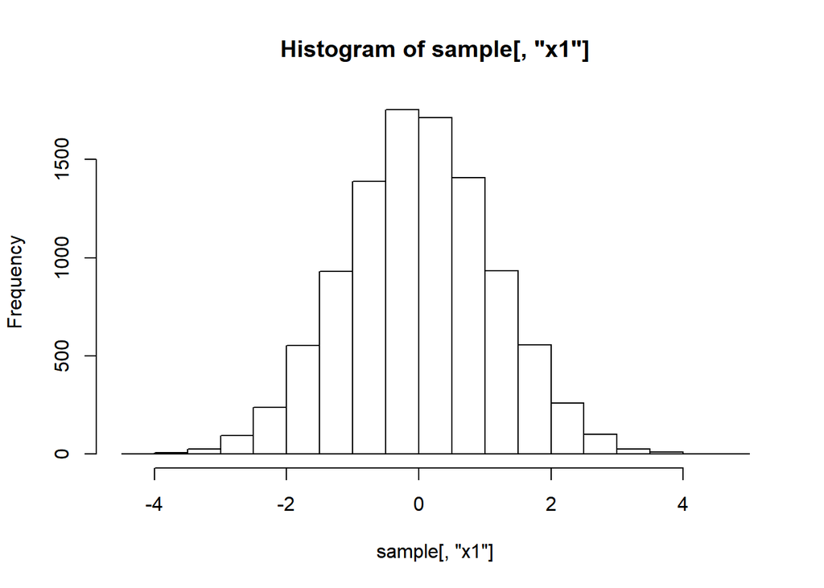

```r
hist(sample[,"x1"],freq = TRUE)
```

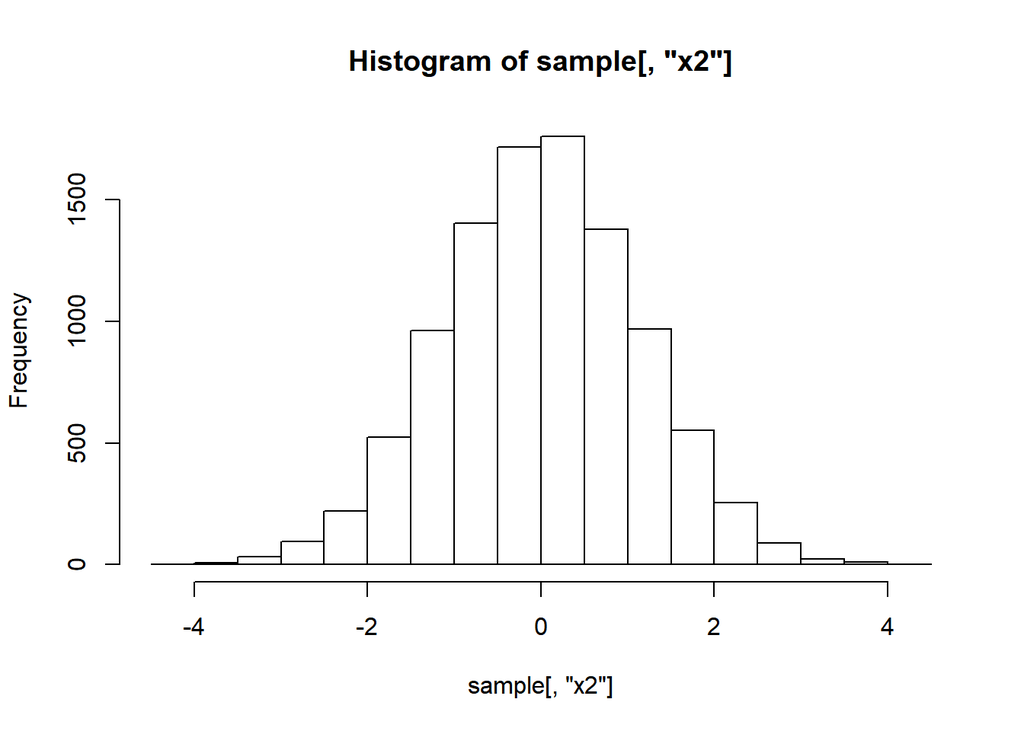

```r
hist(sample[,"x2"],freq = TRUE)
```

As we can see from the marginal empirical distribution of $x_1$ and $x_2$, their distribution approximates a normal distribution.